# Survival Analysis Demo

[figure not shown]

[figure not shown]

[figure not shown]

[figure not shown]

[figure not shown]

[figure not shown]

### About

Radiotherapy has dramatically improved prognosis for patients with Hodgkin disease (HD) in the last several decades. Unfortunately, its carcinogenic nature has caused a significant increase in the risk of secondary malignancies in HD survivors. Secondary cancers are the leading cause of death among 15-year HD survivors. Breast cancer is the most common solid tumor diagnosed in female HD survivors and the risk varies with patient and treatment-related factors.

The dataset used in this demo contains breast cancer incidence in HD female survivors, as well as age at treatment, site treated, ovarian function, radiotherapy dose, and other treatment modalities.

The goal is to investigate the time to the onset of breast cancer in patients with HD treated with and without radiotherapy. In search for an adequate model for the data, we tried a number of survival models, namely, the non-parametric Kaplan Meier estimates, the classic cox regression, the proportional odds model and the PHPH cure model, investigating difference in breast cancer specific survival probabilities between patients who received radiotherapy and patients who did not.

Made by [Cabaceo LLC](https://cabaceo.com).

### Time to breast cancer

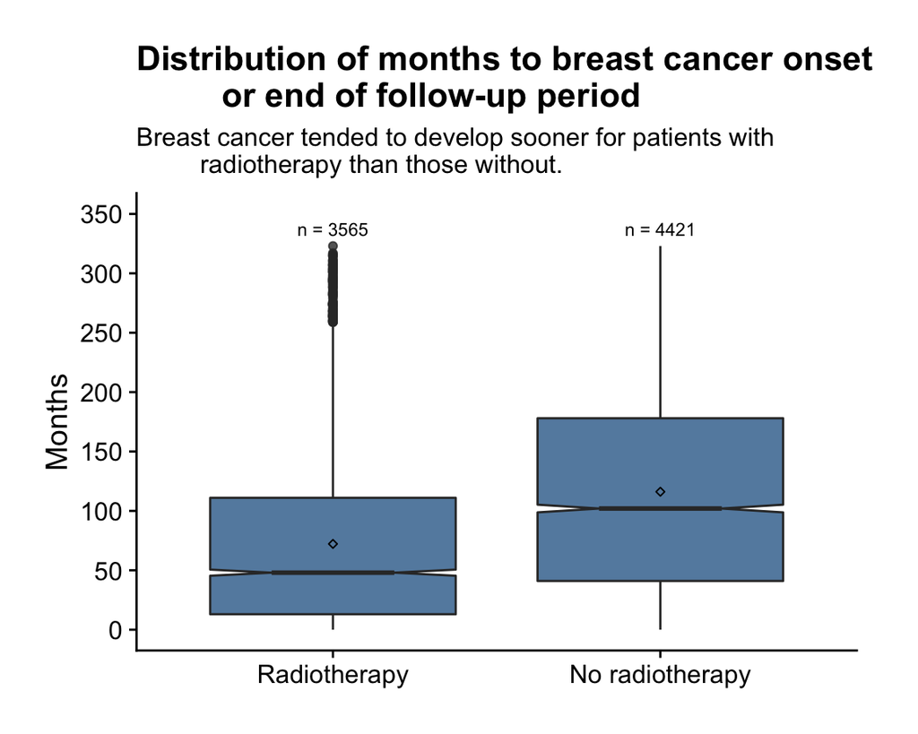

### Breast cancer incidents

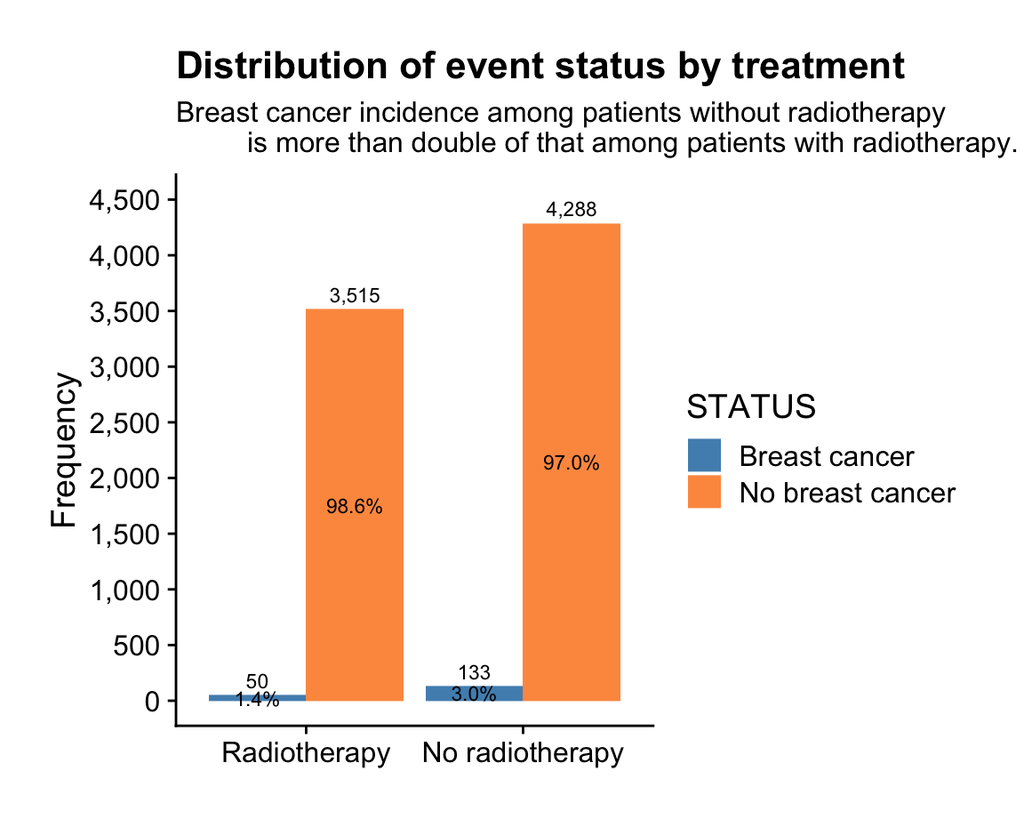

### Kaplan Meier

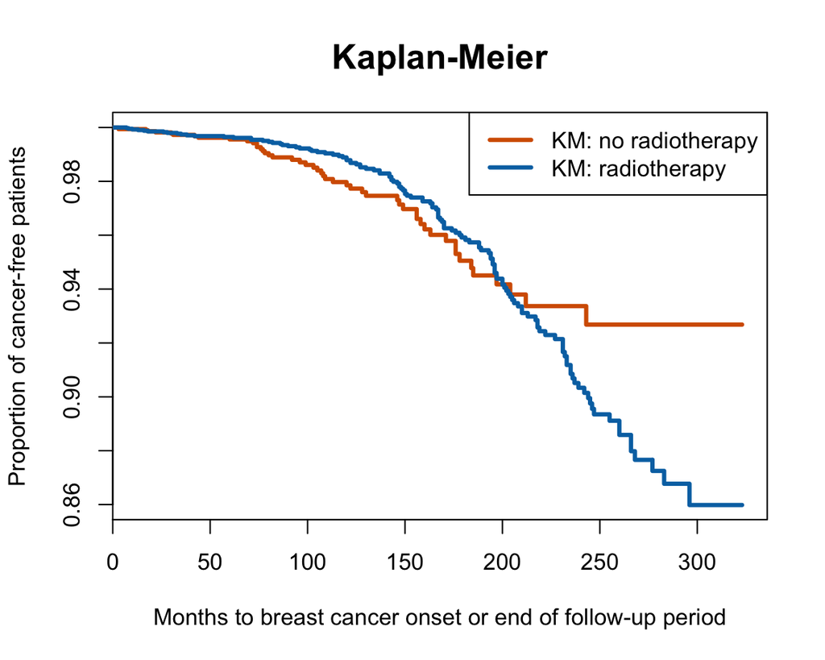

Looking at the Kaplan-Meier curves on the left, we see in the short term, patients who received radiotherapy had a higher proportion of cancer-free patients and hence lower breast cancer incidence than patients without radiotherapy, but in the long term, patients with radiotherapy had a higher breast cancer incidence than patients without. This observation leads to the following hypothesis: radiotherapy decreases the risk of breast cancer in the short term, but increases the risk in the long term.

### Cox Model

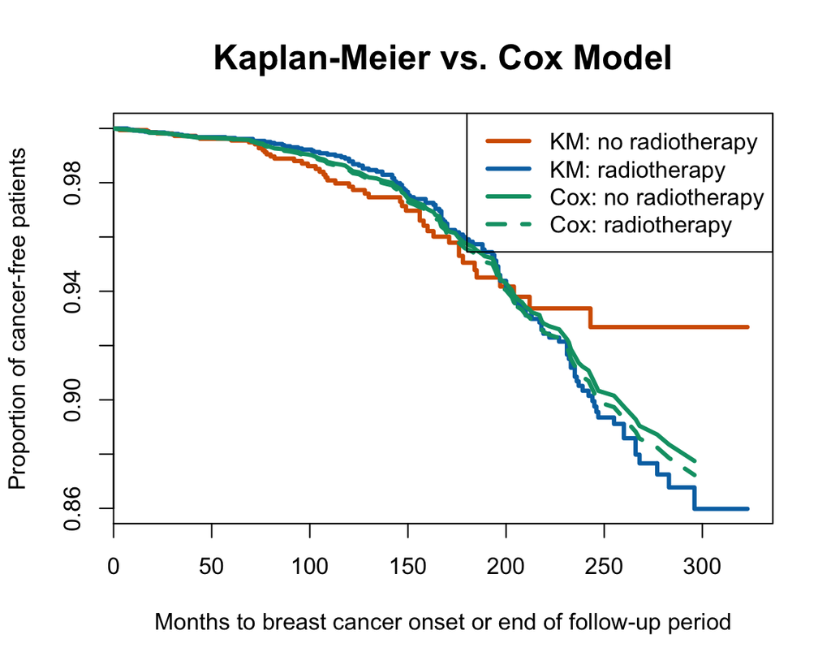

Model parameter estimate

| term | est | exp(est) | p-val |
| --- | --- | --- | --- |
| RTNo radiotherapy | 0.044 | 1.045 | 0.791 |

The parameter estimate of the treatment variable has a p-value greater than 0.05, indicating the effect of radiotherapy is not statistically significant under the Cox model.

This plot on the left shows the Cox model fits the data poorly. The cox model fails to describe the data because it doesn’t account for the possibility that short and long term effects of the treatment on the hazard can be in opposite direction.

### PO Model

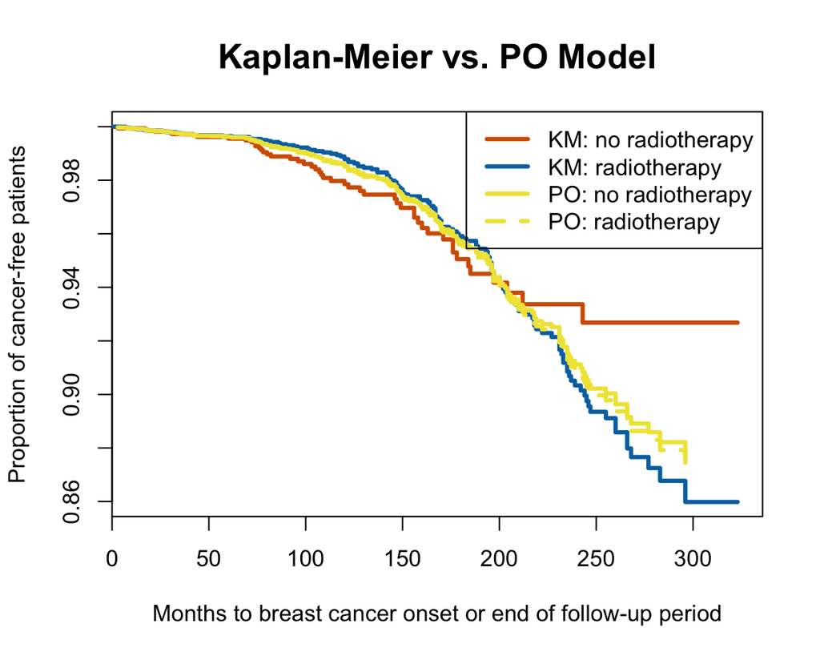

Model parameter estimate

| term | est | exp(est) | p-val |
| --- | --- | --- | --- |
| RTNo radiotherapy | -0.028 | 0.972 | 0.87 |

The parameter estimate of the treatment variable has a p-value greater than 0.05, indicating the effect of radiotherapy is not statistically significant under the proportional odds model.

The plot on the left shows the proportional odds model fits the data poorly. The PO model fails to describe the data because the it also doesn’t account for the possibility that short and long term effects of the treatment on the hazard can be in opposite direction.

### PHPH Model

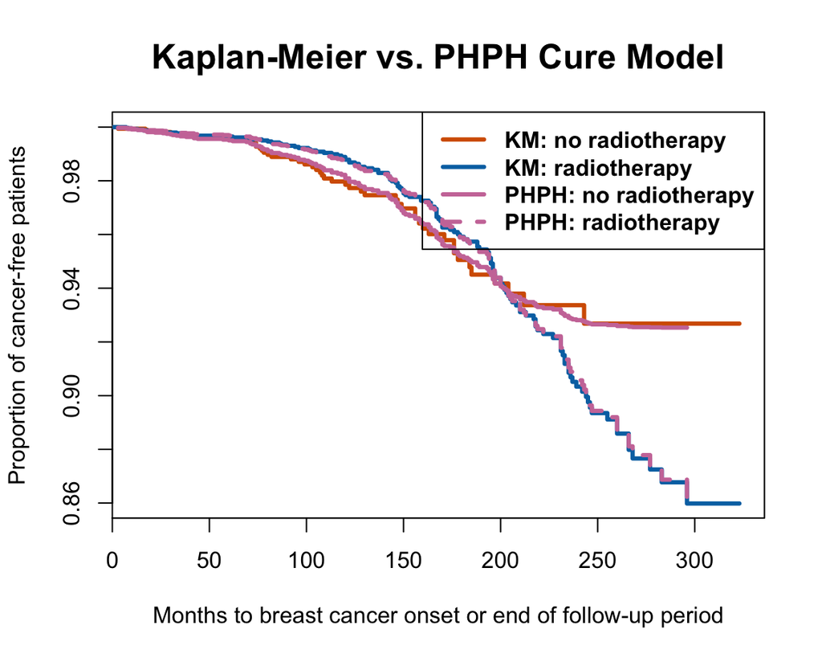

Model parameter estimate

| term | est | exp(est) | p-val |
| --- | --- | --- | --- |
| RTNo radiotherapy | 0.694 | 2.002 | 0.002 |
| RTNo radiotherapy | -1.163 | 0.313 | 0 |
| cure | -2.556 | 0.078 | 0 |

The p-values are tiny, indicating the beta estimates are all statistically significant. In particular, the significant beta estimate for radiotherapy in the short term predictor implies radiotherapy has a negative effect on breast cancer incidence in the short term; the significant beta estimate for radiotherapy in the long term predictor implies radiotherapy has a positive effect on breast cancer incidence in the long run.

The plot on the left shows the PHPHC cure model fits the data well. This is because the phph cure model includes a term that captures the short term effect explicitly.